# Structural body size over time in Atlantic Forest passerines

- Show All Code
- Hide All Code
- View Source

A descriptive inquiry into four size proxies — wing, tail, tarsus, body mass

Author

Atlantic Birds project

Published

June 14, 2026

## 1 The puzzle, widened

The main analysis of this project found that **wing length declined** across 89 Atlantic Forest passerine species between 1990 and 2018 (Bayesian phylogenetic multilevel model, standardized year effect **β = −0.73 mm** per SD-year, 95 % CI −1.09 to −0.37, excluding zero), while a parallel model for **log body mass** found essentially **no trend** (β = −0.001 log-g per SD-year, 95 % CI −0.008 to +0.006). If birds are getting structurally smaller, why does their mass not shrink too?

This report explores that question descriptively across **four proxies of body size**: two flight-feather traits — **wing length** and **tail length** — a leg/skeletal trait, **tarsus length**, and the soft-tissue measure, **body mass**. Tarsus is conceptually the cleanest index of structural size; mass the crudest (it fluctuates with gut content, fat, hydration); the feather traits sit in between and additionally carry molt/wear signals. Throughout, we also track whether each bird was measured **live or as a museum specimen**, since preservation can bias measurements and could confound a temporal trend (developed in the descriptive section below and tested formally in Section 13). The result is richer than the original two-trait puzzle:

> The four proxies **do not move together**. Within species, wing length declines, tarsus length *increases*, and tail length and body mass show no net change — so the wing decline is not a coordinated whole-body shrinkage. But the *shape* of the trends matters: wing length and tail length (the two feather traits) both fall sharply in the most recently sampled years, a recent signal a single linear slope hides.

## 2 Reproducing the analytical sample

We rebuild the exact analytical frame used by the project’s models directly from the raw ATLANTIC BIRD TRAITS csv (filters: `Year ≥ 1990`, adult, known sex, Passeriformes, inside the 20-km Atlantic Forest buffer; then species with ≥ 30 records and a ≥ 5-year span). This reproduces the canonical sample of **15,332 records / 89 species** exactly. Wing, tail and tarsus each coalesce right/left/unspecified measurements the way the project’s wing variable is built.

```python
RAW = "../data/raw/ATLANTIC_BIRD_TRAITS_completed_2018_11_d05.csv"
b = pd.read_csv(RAW, low_memory=False)

mask = (
    (b.Year >= 1990) & (b.Age == "Adult") &
    (b.Sex.isin(["Male", "Female"])) &          # R's filter drops NA sex too
    (b.Order == "Passeriformes") &
    (b.AtlanticForests_20km_Buffer == "inside the 20 km polygon")
)
d = b[mask].copy()
d["cwl"]  = (d["Wing_length_right.mm."].combine_first(d["Wing_length_left.mm."])
             .combine_first(d["Wing_length.mm."]))
d["ctail"] = (d["Tail_length_right.mm."].combine_first(d["Tail_length_left.mm."])
              .combine_first(d["Tail_length.mm."]))
d["ctar"] = (d["Tarsus_length_right.mm."].combine_first(d["Tarsus_length_left.mm."])
             .combine_first(d["Tarsus_length.mm."]))
d["Binomial"] = d["Binomial"].str.replace(" ", "_")
d = d[d.groupby("Binomial")["Binomial"].transform("size") >= 30].copy()
d = d[d.groupby("Binomial")["Year"].transform(lambda x: x.max() - x.min()) >= 5].copy()

d["scaled_yr"]  = (d.Year - d.Year.mean()) / d.Year.std()
d["scaled_lat"] = ((-d.Latitude_decimal_degrees) - (-d.Latitude_decimal_degrees).mean()) \
                   / (-d.Latitude_decimal_degrees).std()
d["mass"] = d["Body_mass.g."]
for resp, src in SRC.items():
    d[resp] = np.log(d[src])
YR_SD = d.Year.std()

print(f"Records: {len(d):,}   Species: {d.Binomial.nunique()}   (expect 15,332 / 89)\n")
print("Trait coverage within the sample (and species with ≥30 records of the trait):")
for resp in ORDER:
    src = SRC[resp]; sub = d.dropna(subset=[src])
    n30 = (sub.groupby("Binomial").size() >= 30).sum()
    print(f"  {LAB[resp]:14s}: {sub[src].notna().sum():>6,} records, "
          f"{sub.Binomial.nunique():>2} species ({n30} with ≥30)")
print(f"\nYear SD (for per-SD ↔ per-year conversion): {YR_SD:.2f} years")
```

```
Records: 15,332   Species: 89   (expect 15,332 / 89)

Trait coverage within the sample (and species with ≥30 records of the trait):
  wing length   :  9,864 records, 86 species (71 with ≥30)
  tail length   : 10,308 records, 86 species (69 with ≥30)
  tarsus length :  9,825 records, 86 species (69 with ≥30)
  body mass     : 13,761 records, 89 species (87 with ≥30)

Year SD (for per-SD ↔ per-year conversion): 5.37 years
```

All four traits are well sampled (~10,000–14,000 records). Body mass is actually the *best* sampled, so nothing here is limited by data volume.

## 3 A first note on data quality (tarsus)

Tarsus length contains some physically impossible values — passerine tarsi run roughly 10–35 mm, yet a handful exceed 50 mm (e.g. a 192 mm tarsus on a *Herpsilochmus* antwren, ~18 mm in life). These are data-entry errors. We keep all records in the main analysis for consistency with the project’s pipeline (which likewise keeps a 480 g mass outlier), but flag the issue here and show the tarsus trend is **robust to removing implausible values** — it even strengthens. A systematic, four-trait outlier analysis follows in Section 12.

```python
def mixed_yr(df, resp):
    sub = df.dropna(subset=[resp]).copy()
    f = smf.mixedlm(f"{resp} ~ C(Sex) + scaled_yr + scaled_lat", sub,
                    groups=sub["Binomial"], re_formula="~scaled_yr").fit(method="lbfgs")
    b1, se = f.params["scaled_yr"], f.bse["scaled_yr"]
    return b1, se, f.pvalues["scaled_yr"], len(sub)

imp = d.ctar.notna() & ((d.ctar < 5) | (d.ctar > 40))
print(f"Implausible tarsus records (<5 or >40 mm): {imp.sum()} of {d.ctar.notna().sum()}")
for name, df in [("all records", d), ("plausible 5–40 mm only", d[~imp])]:
    b1, se, p, n = mixed_yr(df, "lntar")
    print(f"tarsus, {name:24s}: β_yr = {b1:+.4f} "
          f"[{b1-1.96*se:+.4f}, {b1+1.96*se:+.4f}], p = {p:.3f}, N = {n:,}")
```

```
Implausible tarsus records (<5 or >40 mm): 35 of 9825
tarsus, all records             : β_yr = +0.0117 [+0.0011, +0.0223], p = 0.030, N = 9,825
tarsus, plausible 5–40 mm only  : β_yr = +0.0129 [+0.0056, +0.0202], p = 0.001, N = 9,790
```

## 4 What the four traits look like

Each bird was measured either **live** (mist-netting) or as a **museum** specimen, and we carry that distinction through from here. The colours below are fixed: **live** and **museum**.

```
Sample by measurement status: live 13,102 | museum 2,202 | unknown 28
```

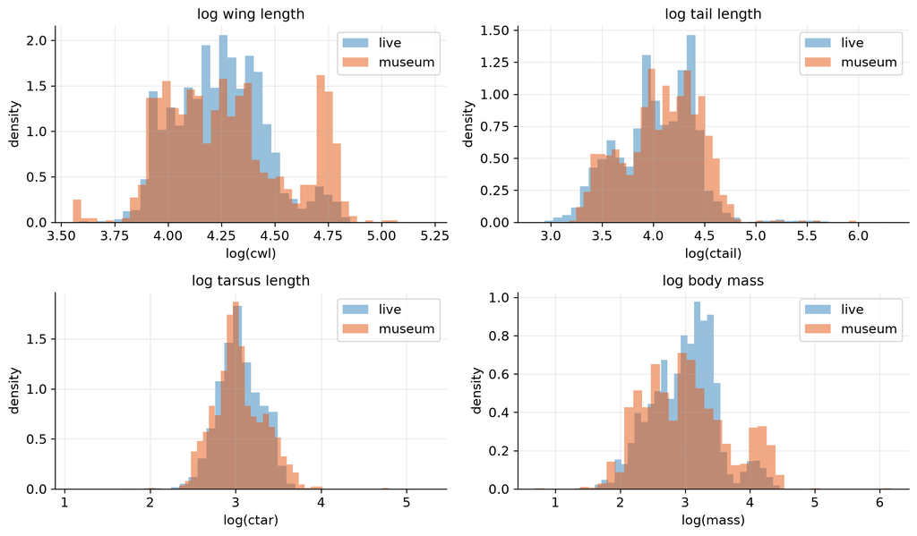

Figure 1: Distributions on the modelled log scale, overlaid by measurement status (density-normalised so the two groups are comparable despite very different sample sizes). The live and museum distributions broadly overlap for every trait — at the whole-sample scale, between-species variation dwarfs any status effect.

```
           cwl     ctail     ctar      mass
count  9864.00  10308.00  9825.00  13761.00
mean     71.92     60.51    21.77     23.21
std      16.79     24.90     6.02     14.21
min      35.00     17.30     3.00      2.00
25%      59.55     44.00    17.90     14.00
50%      70.00     57.38    20.80     20.50
75%      80.50     75.40    25.10     28.00
max     185.00    555.00   192.00    480.00
```

```python
fig, ax = plt.subplots(2, 2, figsize=(11, 6.5))
for a, resp in zip(ax.ravel(), ORDER):
    for st, c in [("live", LIVE_C), ("museum", MUS_C)]:
        x = ds.loc[ds.Status == st, resp].dropna()
        a.hist(x, bins=40, density=True, color=c, alpha=.5, label=st)
    a.set_title(f"log {LAB[resp]}"); a.set_xlabel(f"log({SRC[resp]})")
    a.set_ylabel("density"); a.legend()
plt.tight_layout(); plt.show()

print(d[[SRC[r] for r in ORDER]].describe().round(2).to_string())
```

At the whole-sample scale the live and museum curves sit almost on top of each other, because between-species variation is enormous (and exactly why pooling across species, next, is the wrong tool). But that overlap *hides* the status effect: a 5 % shift in tail is invisible against a trait that varies several-fold across species. To expose it we re-plot the same data as **within-species deviations** (each record minus its species mean), which removes the between-species spread:

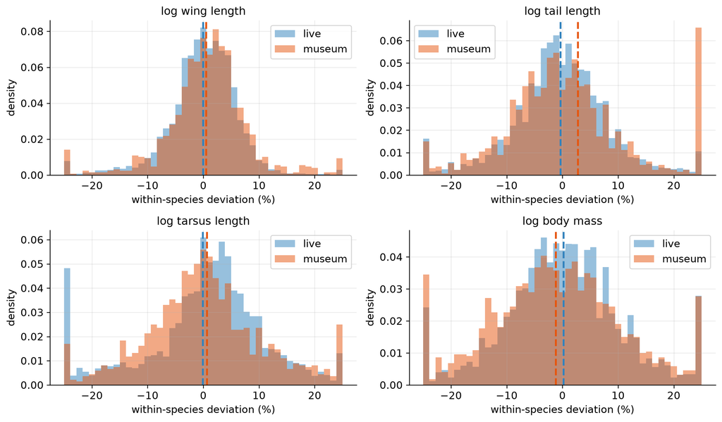

Figure 2: Within-species deviations (% from each species’ mean) by status. Once between-species spread is removed, the systematic museum bias is clear: museum tail length reads longer and museum body mass lighter, while wing is essentially unaffected. Dashed lines = group means. This is the same effect quantified in Section 13.

```python
fig, ax = plt.subplots(2, 2, figsize=(11, 6.5))
for a, resp in zip(ax.ravel(), ORDER):
    sub = ds.dropna(subset=[resp]).copy()
    sub["dev"] = (sub[resp] - sub.groupby("Binomial")[resp].transform("mean")) * 100
    for st, c in [("live", LIVE_C), ("museum", MUS_C)]:
        x = np.clip(sub.loc[sub.Status == st, "dev"], -25, 25)
        a.hist(x, bins=45, density=True, color=c, alpha=.5, label=st)
        a.axvline(sub.loc[sub.Status == st, "dev"].mean(), color=c, ls="--", lw=2)
    a.set_title(f"log {LAB[resp]}"); a.set_xlabel("within-species deviation (%)")
    a.set_ylabel("density"); a.legend()
plt.tight_layout(); plt.show()
```

```python
rows = []
for resp in ORDER:
    src = SRC[resp]
    for st in ["live", "museum"]:
        x = ds.loc[(ds.Status == st), src].dropna()
        dev = (ds.loc[ds.Status == st, resp] -
               ds.groupby("Binomial")[resp].transform("mean")).dropna()
        rows.append([LAB[resp], st, f"{len(x):,}", f"{x.mean():.2f}", f"{x.median():.2f}",
                     f"{x.std()/x.mean():.3f}", f"{dev.mean()*100:+.2f}%"])
pd.DataFrame(rows, columns=["trait","status","n","mean","median","CV","mean within-spp dev"])
```

Table 1

|  | trait | status | n | mean | median | CV | mean within-spp dev |
| --- | --- | --- | --- | --- | --- | --- | --- |
| 0 | wing length | live | 8,700 | 71.45 | 70.00 | 0.221 | -0.07% |
| 1 | wing length | museum | 1,154 | 75.42 | 70.06 | 0.302 | +0.51% |
| 2 | tail length | live | 9,094 | 60.13 | 57.00 | 0.413 | -0.37% |
| 3 | tail length | museum | 1,204 | 63.38 | 60.51 | 0.397 | +2.78% |
| 4 | tarsus length | live | 8,594 | 21.76 | 20.90 | 0.268 | -0.09% |
| 5 | tarsus length | museum | 1,223 | 21.87 | 20.20 | 0.330 | +0.66% |
| 6 | body mass | live | 11,754 | 22.70 | 21.00 | 0.546 | +0.20% |
| 7 | body mass | museum | 1,985 | 25.88 | 20.00 | 0.830 | -1.20% |

Descriptive statistics by measurement status.

The descriptive table makes the point numerically: museum specimens read longer in tail (and slightly in tarsus) and lighter in mass, with wing barely touched. Since museum specimens are not evenly spread over time, we test whether this biases the *trends* in Section 13 — it does not for wing, tarsus or mass, and only matters for tail.

## 5 The trap: pooling across species reverses the sign

A naïve approach regresses each trait on year across *all* records at once, with the covariates the models use (sex, latitude).

```python
rows = []
for resp in ORDER:
    sub = d.dropna(subset=[resp])
    f = smf.ols(f"{resp} ~ scaled_yr + C(Sex) + scaled_lat", data=sub).fit()
    b1 = f.params["scaled_yr"]; lo, hi = f.conf_int().loc["scaled_yr"]
    rows.append([f"log {LAB[resp]}", len(sub), fmt(b1), f"[{fmt(lo)}, {fmt(hi)}]"])
pd.DataFrame(rows, columns=["trait", "N", "β (per SD-yr, log)", "95% CI"])
```

|  | trait | N | β (per SD-yr, log) | 95% CI |
| --- | --- | --- | --- | --- |
| 0 | log wing length | 9864 | +0.0093 | [+0.0050, +0.0136] |
| 1 | log tail length | 10308 | +0.0164 | [+0.0091, +0.0236] |
| 2 | log tarsus length | 9825 | +0.0200 | [+0.0149, +0.0251] |
| 3 | log body mass | 13761 | +0.0203 | [+0.0112, +0.0294] |

Several naïve pooled slopes come out **positive** — including wing length, which we *know* declines within species. This is Simpson’s paradox: the pooled slope mixes genuine within-species change with shifts in *which* species were sampled over time, and between-species variation is so large that composition dominates. **The pooled trend is uninformative.** The right question is within-species, which the random-slope structure of the project’s models isolates — reproduced next.

## 6 Within-species trends: the four traits diverge

### 6.1 Per-species slopes

For each species we fit a within-species regression of the log trait on standardized year — the model-free analogue of a random year slope.

```python
def per_species(resp):
    out = []
    for sp, g in d.dropna(subset=[resp]).groupby("Binomial"):
        if g.Year.nunique() < 3 or g[resp].nunique() < 2:
            continue
        out.append(smf.ols(f"{resp} ~ scaled_yr", data=g).fit().params["scaled_yr"])
    return np.array(out)

slopes = {r: per_species(r) for r in ORDER}
rows = []
for resp in ORDER:
    s = slopes[resp]; neg, pos = int((s < 0).sum()), int((s > 0).sum())
    sign_p = stats.binomtest(min(neg, pos), neg + pos).pvalue
    rows.append([f"log {LAB[resp]}", len(s), fmt(np.median(s)), fmt(s.mean()),
                 f"{pos}/{neg+pos}", f"{sign_p:.3f}"])
pd.DataFrame(rows, columns=["trait", "species", "median slope", "mean slope",
                            "increased", "sign-test p"])
```

|  | trait | species | median slope | mean slope | increased | sign-test p |
| --- | --- | --- | --- | --- | --- | --- |
| 0 | log wing length | 85 | -0.0076 | -0.0103 | 27/85 | 0.001 |
| 1 | log tail length | 85 | -0.0043 | +0.0015 | 38/85 | 0.386 |
| 2 | log tarsus length | 85 | +0.0115 | +0.0081 | 58/85 | 0.001 |
| 3 | log body mass | 89 | -0.0073 | -0.0029 | 38/89 | 0.203 |

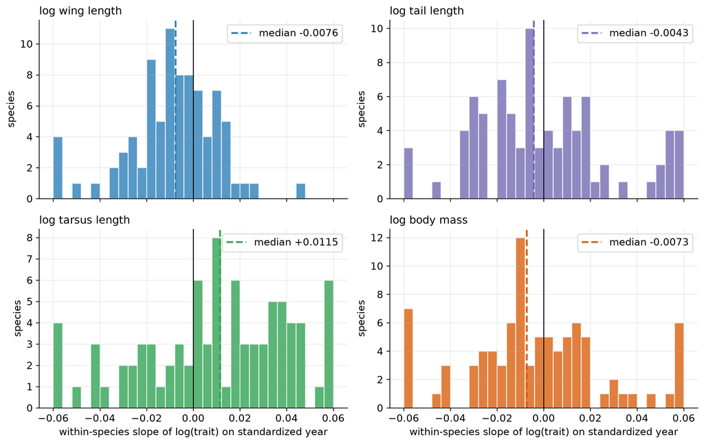

Figure 3: Within-species year slopes (log scale, per SD-year), one panel per trait. Dashed = median, solid black = zero. Wing slopes sit left of zero (most decline); tarsus right of zero (most increase); tail and body mass straddle zero.

```python
fig, ax = plt.subplots(2, 2, figsize=(11, 7), sharex=True)
bins = np.linspace(-0.06, 0.06, 31)
for a, resp in zip(ax.ravel(), ORDER):
    s = np.clip(slopes[resp], bins[0], bins[-1])
    a.hist(s, bins=bins, color=COL[resp], alpha=.8, edgecolor="white")
    a.axvline(np.median(slopes[resp]), color=COL[resp], ls="--", lw=2,
              label=f"median {np.median(slopes[resp]):+.4f}")
    a.axvline(0, color="black", lw=1)
    a.set_title(f"log {LAB[resp]}", loc="left"); a.set_ylabel("species"); a.legend(loc="upper right")
for a in ax[-1]: a.set_xlabel("within-species slope of log(trait) on standardized year")
plt.tight_layout(); plt.show()
```

The four traits point different ways. Wing declines in most species (sign-test p = 0.001); tarsus *increases* in most (p = 0.001); tail and body mass are near coin-flips (p ≈ 0.4 and 0.2).

### 6.2 A like-for-like mixed model

Matching the project’s models without the phylogeny: a random-intercept / random-year-slope mixed model per trait (`trait ~ sex + scaled_yr + scaled_lat + (1 + scaled_yr | species)`).

```python
rows = []
for resp in ORDER:
    b1, se, p, n = mixed_yr(d, resp)
    rows.append([f"log {LAB[resp]}", fmt(b1), f"[{fmt(b1-1.96*se)}, {fmt(b1+1.96*se)}]",
                 f"{p:.3f}", f"{n:,}"])
pd.DataFrame(rows, columns=["trait", "β year (per SD-yr, log)", "95% CI", "p", "N"])
```

|  | trait | β year (per SD-yr, log) | 95% CI | p | N |
| --- | --- | --- | --- | --- | --- |
| 0 | log wing length | -0.0105 | [-0.0156, -0.0054] | 0.000 | 9,864 |
| 1 | log tail length | +0.0025 | [-0.0059, +0.0108] | 0.560 | 10,308 |
| 2 | log tarsus length | +0.0117 | [+0.0011, +0.0223] | 0.030 | 9,825 |
| 3 | log body mass | -0.0023 | [-0.0255, +0.0209] | 0.845 | 13,761 |

Without any phylogenetic machinery this reproduces and extends the headline: **wing length declines** (CI excludes zero, p < 0.001), **tarsus length increases** (p ≈ 0.03; p = 0.001 once impossible values are dropped), and **tail length and body mass show no net trend** (CIs span zero). Three of the four proxies fail to show the wing decline; one moves the opposite way. The flat mass result is not a quirk of the Bayesian model, and the wing decline is clearly *not* a uniform skeletal shrinkage.

## 7 Putting all four traits on a common scale

The original “−0.73 vs −0.001” headline mixes units (mm vs log-grams). Expressing every within-species slope as a **percentage change per decade** (a log slope `β` ≈ a fractional change `expm1(β)`) makes them directly comparable.

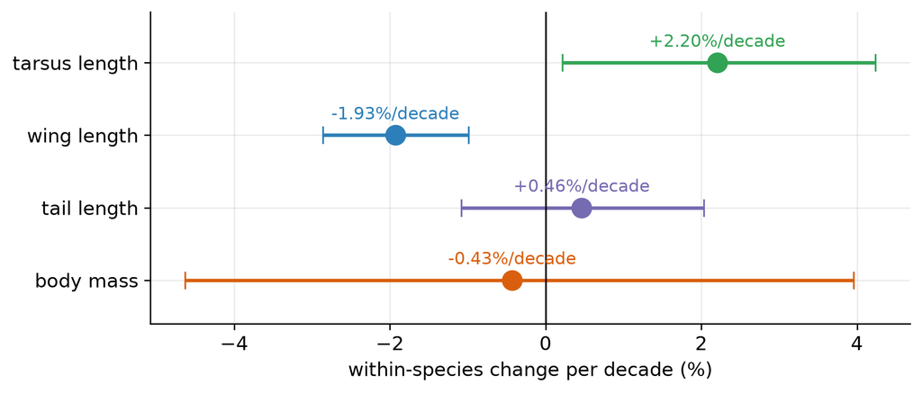

Figure 4: Within-species change per decade (%) with 95% CI (mixed models). Wing length declines ~2%/decade (CI below zero); tarsus rises ~2%/decade (CI above zero); tail length and body mass sit on zero. The proxies diverge in direction and in statistical support.

```
  wing length   : -1.93%/dec  [-2.86, -0.99]
  tail length   : +0.46%/dec  [-1.08, +2.03]
  tarsus length : +2.20%/dec  [+0.21, +4.24]
  body mass     : -0.43%/dec  [-4.63, +3.96]
```

```python
res = {}
for resp in ORDER:
    b1, se, p, n = mixed_yr(d, resp); f = 10 / YR_SD
    res[resp] = (np.expm1(b1*f)*100, np.expm1((b1-1.96*se)*f)*100, np.expm1((b1+1.96*se)*f)*100)

fig, ax = plt.subplots(figsize=(7.5, 3.3))
order = ["lnmass", "lntail", "lnwing", "lntar"]
for i, resp in enumerate(order):
    est, lo, hi = res[resp]
    ax.errorbar(est, i, xerr=[[est-lo],[hi-est]], fmt="o", color=COL[resp], ms=11, capsize=5, lw=2)
    ax.text(est, i+0.22, f"{est:+.2f}%/decade", ha="center", color=COL[resp], fontsize=10)
ax.axvline(0, color="black", lw=1)
ax.set_yticks(range(len(order))); ax.set_yticklabels([LAB[r] for r in order])
ax.set_ylim(-0.6, len(order)-0.3); ax.set_xlabel("within-species change per decade (%)")
plt.tight_layout(); plt.show()
for resp in ORDER:
    e, l, h = res[resp]; print(f"  {LAB[resp]:14s}: {e:+.2f}%/dec  [{l:+.2f}, {h:+.2f}]")
```

On a common footing, wing and tarsus change at *similar magnitudes in opposite directions* (~±2 %/decade), while tail length and body mass barely move. Body mass being flat is therefore corroborated by *two* other proxies, not explained away.

## 8 The shape of the trends over time (non-linearity within 1990–2018)

A single linear slope can hide acceleration, plateaus or reversals. We probe the *shape* of each trend two ways, both on **within-species deviations** (each record minus its species mean, so between-species composition is removed): (1) mean deviation in five time bins, and (2) a LOWESS smoother across years. We do **not** extend before 1990 — only ~1,250 records exist earlier, with essentially no body mass (one record before 1970) and likely different collection methods, so it would add high-leverage noise rather than signal.

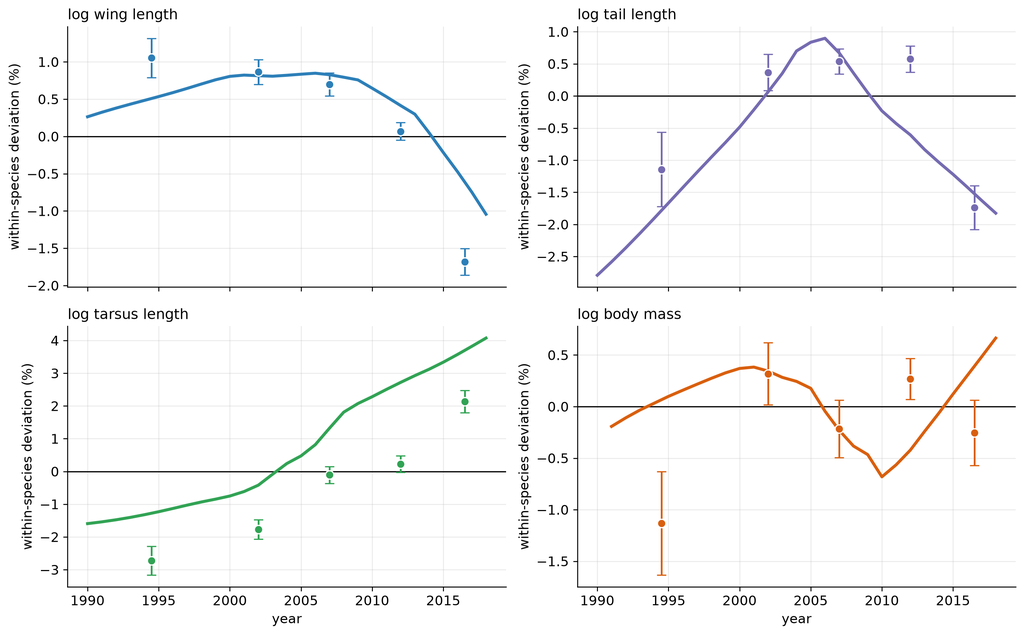

Figure 5: Within-species deviation (%) of each trait over time: dots = mean ± SE in five period bins, line = LOWESS smoother. Wing length (blue) and tail length (purple) — the two feather traits — both fall steeply in the most recently sampled years; tarsus (green) rises steadily; body mass (orange) hugs zero throughout. Note sampling is sparse in the 1990s and densest after 2005.

```python
BINS = [(1990,1999),(2000,2004),(2005,2009),(2010,2014),(2015,2018)]
centers = [np.mean(x) for x in BINS]
fig, ax = plt.subplots(2, 2, figsize=(12, 7.5), sharex=True)
for a, resp in zip(ax.ravel(), ORDER):
    sub = d.dropna(subset=[resp]).copy()
    sub["dev"] = (sub[resp] - sub.groupby("Binomial")[resp].transform("mean")) * 100
    lo = lowess(sub["dev"], sub["Year"], frac=0.6, return_sorted=True)
    a.plot(lo[:,0], lo[:,1], color=COL[resp], lw=2.5, zorder=3)
    for (lo_y, hi_y), c in zip(BINS, centers):
        v = sub[(sub.Year>=lo_y)&(sub.Year<=hi_y)]["dev"]
        a.errorbar(c, v.mean(), yerr=v.sem(), fmt="o", color=COL[resp], ms=7,
                   capsize=4, mec="white", zorder=4)
    a.axhline(0, color="black", lw=1)
    a.set_title(f"log {LAB[resp]}", loc="left"); a.set_ylabel("within-species deviation (%)")
for a in ax[-1]: a.set_xlabel("year")
plt.tight_layout(); plt.show()
```

```python
rows = []
for resp in ORDER:
    sub = d.dropna(subset=[resp]).copy()
    sub["dev"] = sub[resp] - sub.groupby("Binomial")[resp].transform("mean")
    sub["yr2"] = sub["scaled_yr"]**2
    f = smf.ols("dev ~ scaled_yr + yr2", data=sub).fit()
    rows.append([LAB[resp], fmt(f.params["scaled_yr"]), f"{f.pvalues['scaled_yr']:.3f}",
                 fmt(f.params["yr2"], 5), f"{f.pvalues['yr2']:.3f}"])
pd.DataFrame(rows, columns=["trait", "linear β", "linear p", "quadratic β", "quadratic p"])
```

|  | trait | linear β | linear p | quadratic β | quadratic p |
| --- | --- | --- | --- | --- | --- |
| 0 | wing length | -0.0111 | 0.000 | -0.00489 | 0.000 |
| 1 | tail length | -0.0044 | 0.001 | -0.00426 | 0.000 |
| 2 | tarsus length | +0.0109 | 0.000 | +0.00078 | 0.487 |
| 3 | body mass | +0.0012 | 0.425 | -0.00094 | 0.375 |

### 8.1 Controlling for measurement status

Because the museum:live mix changes over time (Section 13), we re-draw each trajectory **separately by status**, centering within species *and* status so that each curve shows only the temporal *shape* within its own measurement type (the constant museum offset is removed).

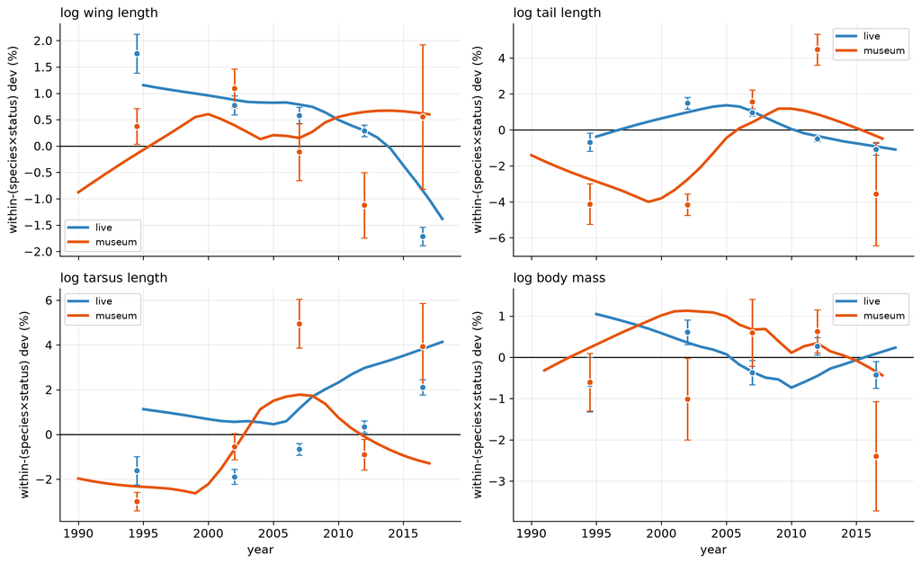

Figure 6: Within-(species×status) deviation (%) over time, split by measurement status — live (blue) and museum (orange); line = LOWESS, dots = period means ± SE (shown where n ≥ 15). The live series (the bulk of the data) reproduces every shape: wing’s recent fall, tarsus’s steady rise, tail’s hump-then-recent-fall, and mass’s flatness. Museum records are sparse — especially after 2010 (≈37–150 records in 2015–2018) — and erratic, but show no systematic opposing pattern. The recent feather-trait drop is clearly a live-data phenomenon, not a preservation artifact.

```python
fig, ax = plt.subplots(2, 2, figsize=(12, 7.5), sharex=True)
for a, resp in zip(ax.ravel(), ORDER):
    sub = ds.dropna(subset=[resp]).copy()
    sub["dev"] = (sub[resp] - sub.groupby(["Binomial", "Status"])[resp].transform("mean")) * 100
    for st, c in [("live", LIVE_C), ("museum", MUS_C)]:
        g = sub[sub.Status == st]
        if len(g) > 30:
            lo = lowess(g["dev"], g["Year"], frac=0.6, return_sorted=True)
            a.plot(lo[:, 0], lo[:, 1], color=c, lw=2.5, label=st, zorder=3)
        for lo_y, hi_y in BINS:
            v = g[(g.Year >= lo_y) & (g.Year <= hi_y)]["dev"]
            if len(v) >= 15:
                a.errorbar(np.mean([lo_y, hi_y]), v.mean(), yerr=v.sem(), fmt="o",
                           color=c, ms=6, capsize=3, mec="white", zorder=4)
    a.axhline(0, color="black", lw=1)
    a.set_title(f"log {LAB[resp]}", loc="left")
    a.set_ylabel("within-(species×status) dev (%)"); a.legend(fontsize=9)
for a in ax[-1]: a.set_xlabel("year")
plt.tight_layout(); plt.show()
```

```python
rows = []
for resp in ORDER:
    sub = ds.dropna(subset=[resp]).copy()
    sub["dev"] = (sub[resp] - sub.groupby(["Binomial", "Status"])[resp].transform("mean")) * 100
    for st in ["live", "museum"]:
        g = sub[sub.Status == st]
        cells = []
        for lo_y, hi_y in BINS:
            v = g[(g.Year >= lo_y) & (g.Year <= hi_y)]["dev"]
            cells.append(f"{v.mean():+.2f}% (n{len(v)})" if len(v) else "—")
        rows.append([LAB[resp], st] + cells)
pd.DataFrame(rows, columns=["trait", "status", "1990–99", "2000–04", "2005–09", "2010–14", "2015–18"])
```

|  | trait | status | 1990–99 | 2000–04 | 2005–09 | 2010–14 | 2015–18 |
| --- | --- | --- | --- | --- | --- | --- | --- |
| 0 | wing length | live | +1.75% (n327) | +0.77% (n1137) | +0.58% (n1765) | +0.29% (n3444) | -1.71% (n2027) |
| 1 | wing length | museum | +0.37% (n211) | +1.09% (n319) | -0.11% (n209) | -1.12% (n378) | +0.55% (n37) |
| 2 | tail length | live | -0.68% (n321) | +1.49% (n987) | +0.97% (n2551) | -0.49% (n3260) | -1.07% (n1975) |
| 3 | tail length | museum | -4.12% (n200) | -4.16% (n319) | +1.56% (n205) | +4.47% (n441) | -3.56% (n39) |
| 4 | tarsus length | live | -1.62% (n326) | -1.89% (n1132) | -0.67% (n2647) | +0.34% (n2849) | +2.10% (n1640) |
| 5 | tarsus length | museum | -2.99% (n208) | -0.55% (n320) | +4.95% (n211) | -0.90% (n445) | +3.94% (n39) |
| 6 | body mass | live | -0.66% (n479) | +0.61% (n1568) | -0.37% (n2817) | +0.27% (n4801) | -0.43% (n2089) |
| 7 | body mass | museum | -0.60% (n263) | -1.01% (n286) | +0.60% (n440) | +0.63% (n850) | -2.40% (n146) |

Read trait by trait, controlled by status:

- **Wing** — the **live** series carries the whole story: gently above the species mean through the 2000s, then a sharp drop in 2015–2018 (−1.7 %). Museum wing is flat/noisy on a small sample and does not reproduce (or oppose) the decline.
- **Tarsus** — the steady increase is clear in the **live** series (−1.6 % → +2.1 %); museum tarsus is erratic but ends positive too.
- **Tail** — the hump-then-recent-fall holds in the **live** series; museum tail swings wildly (a function of ~200–440 records spread thinly across years) and is best disregarded for shape.
- **Body mass** — flat in **both** status groups across every period; the only notable museum point is a 2015–2018 dip on just ~150 records, well within noise.

So the temporal shapes are **properties of the live data**, not of the changing museum fraction. Museum specimens are too few — and too unevenly spread across years — to define a trajectory, but where they appear they do not contradict the live series.

So “deeper time changes” exist — but as **non-linearity within 1990–2018**, not something recoverable by extending the record backward. The most striking is that the wing (and tail) decline is a recent phenomenon, robust to measurement status, which the project’s linear slope understates.

## 9 Signal-to-noise: how blunt is each instrument?

Part of why body mass is uninformative is that it is a much noisier index of size. We quantify this with the within-species coefficient of variation (CV) per trait (each on the species with ≥ 30 records of it).

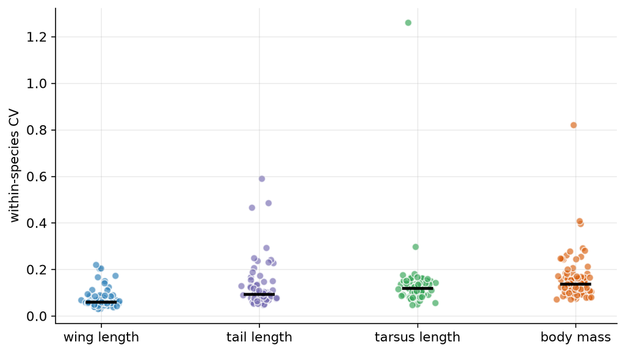

Figure 7: Within-species coefficient of variation by trait (one point per species; black bar = median). Wing length is the cleanest (~0.06), tail and tarsus intermediate, body mass the noisiest (~0.14). High individual-level noise lowers power to resolve a small temporal shift — but tarsus, though noisier than wing, still resolves a clear (opposite) trend, so noise alone cannot explain the flat traits.

```
Median within-species CV:
  wing length   : 0.059
  tail length   : 0.093
  tarsus length : 0.119
  body mass     : 0.137
```

```python
cvrows = []
for resp in ORDER:
    src = SRC[resp]; sub = d.dropna(subset=[src])
    cvs = sub.groupby("Binomial").apply(lambda g: g[src].std()/g[src].mean()
                                        if len(g) >= 30 else np.nan).dropna()
    for v in cvs: cvrows.append((LAB[resp], v))
cv = pd.DataFrame(cvrows, columns=["trait", "cv"])

fig, ax = plt.subplots(figsize=(7.5, 4.3))
for j, resp in enumerate(ORDER):
    vals = cv.loc[cv.trait == LAB[resp], "cv"].values
    jit = np.random.RandomState(j).normal(0, .05, len(vals))
    ax.scatter(np.full(len(vals), j)+jit, vals, color=COL[resp], alpha=.65, edgecolor="white")
    ax.scatter(j, np.median(vals), color="black", marker="_", s=700, lw=2.5, zorder=3)
ax.set_xticks(range(len(ORDER))); ax.set_xticklabels([LAB[r] for r in ORDER])
ax.set_ylabel("within-species CV"); plt.tight_layout(); plt.show()

print("Median within-species CV:")
for resp in ORDER:
    print(f"  {LAB[resp]:14s}: {cv.loc[cv.trait==LAB[resp],'cv'].median():.3f}")
```

Body mass carries ~2.4× the within-species noise of wing length; tail and tarsus are intermediate. Noise is part of why mass is uninformative — but **not** the whole story: tarsus is noisier than wing yet still resolves a clear opposite trend, proving the flat traits cannot be blamed on noise alone.

## 10 Does the mass–wing relationship shift? (allometry / condition)

If wing shrinks while mass holds, are birds heavier *for their wing*? We regress log mass on log wing within species and test whether the residual (“mass-for-wing” condition index) trends over time.

```python
bw = d.dropna(subset=["lnmass", "lnwing"]).copy()
allo = smf.mixedlm("lnmass ~ lnwing", bw, groups=bw["Binomial"],
                   re_formula="~lnwing").fit(method="lbfgs")
bw["cond"] = bw["lnmass"] - (allo.params["Intercept"] + allo.params["lnwing"]*bw["lnwing"])
ct = smf.mixedlm("cond ~ scaled_yr", bw, groups=bw["Binomial"],
                 re_formula="~scaled_yr").fit(method="lbfgs")
b1, se = ct.params["scaled_yr"], ct.bse["scaled_yr"]
print(f"Within-species allometric slope (log mass ~ log wing): {allo.params['lnwing']:.2f}")
print(f"Mass-for-wing (condition) trend: {b1:+.4f} [{b1-1.96*se:+.4f}, {b1+1.96*se:+.4f}] "
      f"per SD-yr, p = {ct.pvalues['scaled_yr']:.3f}")
```

```
Within-species allometric slope (log mass ~ log wing): 0.39
Mass-for-wing (condition) trend: +0.0047 [-0.0026, +0.0120] per SD-yr, p = 0.205
```

The within-species allometric slope is shallow (~0.4): wing explains only a modest fraction of individual mass variation, so the two are partly decoupled. The mass-for-wing residual shows **no significant temporal trend** (p ≈ 0.20). The size proxies are loosely yoked — a change in one need not appear in the others.

## 11 Sanity check: early-vs-late quartile comparison

The model-free comparison the project reports for each trait — mean log trait in the early (≤ 2006) vs late (≥ 2013) period, per species.

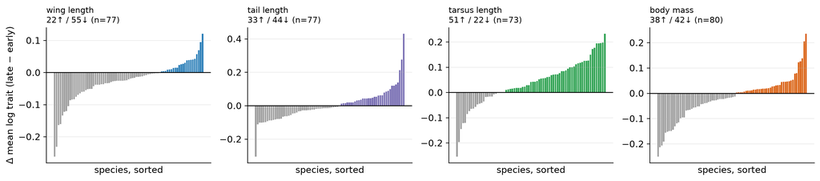

Figure 8: Per-species change in mean log trait, late (≥2013) minus early (≤2006). Wing: most species decrease. Tarsus: most increase. Tail and body mass: roughly even.

```python
pq = d[(d.Year <= 2006) | (d.Year >= 2013)].copy()
pq["period"] = np.where(pq.Year <= 2006, "early", "late")
def quartile(resp):
    t = (pq.dropna(subset=[resp]).groupby(["Binomial","period"])[resp].mean().unstack().dropna())
    return (t["late"] - t["early"]).sort_values()

fig, ax = plt.subplots(1, 4, figsize=(14, 3.2))
for a, resp in zip(ax, ORDER):
    dd = quartile(resp)
    a.bar(range(len(dd)), dd.values, color=[COL[resp] if v>0 else "#9e9e9e" for v in dd.values])
    a.axhline(0, color="black", lw=1); a.set_xticks([])
    a.set_title(f"{LAB[resp]}\n{(dd>0).sum()}↑ / {(dd<0).sum()}↓ (n={len(dd)})", loc="left", fontsize=10)
    a.set_xlabel("species, sorted")
ax[0].set_ylabel("Δ mean log trait (late − early)")
plt.tight_layout(); plt.show()
```

The quartile picture matches the slopes: wing down, tarsus up, tail and mass split.

## 12 Within-species outliers and their influence on the trends

How far do the results depend on a few aberrant records *within species*? We detect within-species outliers with a robust rule, cross-check them against an independent signal (left vs right measurements), and re-estimate every trend with the outliers removed or tamed.

### 12.1 Detecting within-species outliers (robust MAD rule)

For each species and trait we compute a **robust z-score** on the log scale, `z = (log x − median) / (1.4826 · MAD)`. Median/MAD are themselves resistant to outliers, so a single aberrant value cannot define the threshold. We flag `|z| > 3.5`.

```python
def mad_z(df, resp):
    g = df.groupby("Binomial")[resp]
    med = g.transform("median")
    mad = g.transform(lambda x: (x - x.median()).abs().median()) * 1.4826
    return (df[resp] - med) / mad.replace(0, np.nan)

rows = []
for resp in ORDER:
    z = mad_z(d, resp); n = d[resp].notna().sum()
    rows.append([LAB[resp], f"{n:,}"] +
                [f"{(z.abs()>t).sum()} ({(z.abs()>t).mean()*100:.2f}%)" for t in (3.5, 4, 5)])
pd.DataFrame(rows, columns=["trait", "N", "|z|>3.5", "|z|>4", "|z|>5"])
```

|  | trait | N | \|z\|>3.5 | \|z\|>4 | \|z\|>5 |
| --- | --- | --- | --- | --- | --- |
| 0 | wing length | 9,864 | 263 (1.72%) | 199 (1.30%) | 127 (0.83%) |
| 1 | tail length | 10,308 | 325 (2.12%) | 253 (1.65%) | 169 (1.10%) |
| 2 | tarsus length | 9,825 | 529 (3.45%) | 370 (2.41%) | 181 (1.18%) |
| 3 | body mass | 13,761 | 440 (2.87%) | 337 (2.20%) | 214 (1.40%) |

Outliers are uncommon in every trait (most frequent in tarsus, ~3.4 %; least in wing, ~1.7 %). The most extreme records are unambiguous data errors — decimal shifts, dropped digits, unit confusion:

```python
worst = []
for resp in ORDER:
    src = SRC[resp]; z = mad_z(d, resp)
    tmp = d.assign(absz=z.abs()).nlargest(3, "absz")
    for _, r in tmp.iterrows():
        med = d.loc[d.Binomial == r.Binomial, src].median()
        worst.append([LAB[resp], r.Binomial.replace("_"," "), f"{r[src]:.1f}",
                      f"{med:.1f}", f"{r.absz:.0f}", int(r.Year)])
pd.DataFrame(worst, columns=["trait","species","value","species median","MAD-z","year"])
```

|  | trait | species | value | species median | MAD-z | year |
| --- | --- | --- | --- | --- | --- | --- |
| 0 | wing length | Tangara palmarum | 45.0 | 96.4 | 49 | 2010 |
| 1 | wing length | Tangara palmarum | 68.0 | 96.4 | 23 | 2008 |
| 2 | wing length | Antilophia galeata | 185.0 | 78.0 | 22 | 2012 |
| 3 | tail length | Tangara cayana | 555.0 | 51.5 | 56 | 2017 |
| 4 | tail length | Pyriglena leucoptera | 20.0 | 77.1 | 25 | 2007 |
| 5 | tail length | Tangara cayana | 145.0 | 51.5 | 24 | 2009 |
| 6 | tarsus length | Herpsilochmus atricapillus | 192.0 | 18.8 | 73 | 2008 |
| 7 | tarsus length | Conopophaga lineata | 3.0 | 29.7 | 37 | 2005 |
| 8 | tarsus length | Rhopias gularis | 6.9 | 20.3 | 21 | 2012 |
| 9 | body mass | Turdus leucomelas | 6.8 | 69.0 | 26 | 2017 |
| 10 | body mass | Tangara cayana | 4.0 | 19.3 | 25 | 2013 |
| 11 | body mass | Formicivora grisea | 2.0 | 10.0 | 21 | 2008 |

A 192 mm tarsus where the species sits at 19 mm, a 6.8 g thrush where it sits at 69 g (a dropped digit) — clerical, not biological. Do they move the trends?

### 12.2 Cross-check: left vs right measurements

Where both sides were measured, the two should agree to within a couple of percent; large asymmetries flag error independently of the MAD rule. (Tail and mass have too few paired-side records to assess.)

```
wing: median 1.40% | >5%: 73 | >10%: 54
tarsus: median 1.14% | >5%: 8 | >10%: 1
```

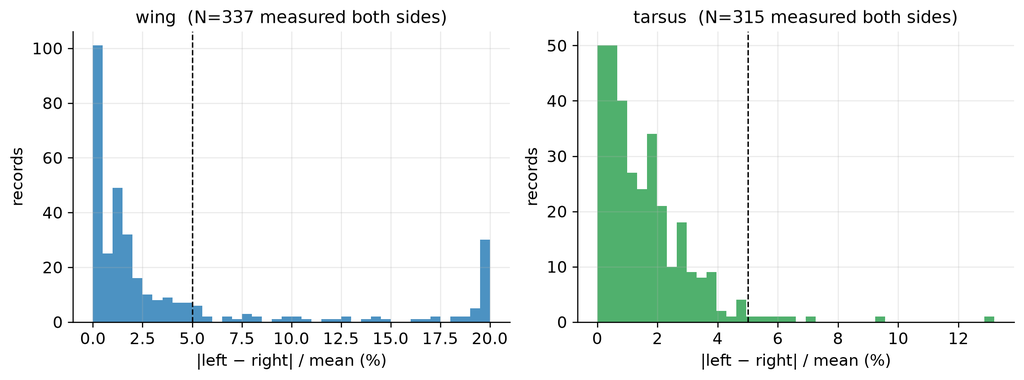

Figure 9: Relative left–right difference |L−R|/mean for records measured on both sides. Tarsus is highly self-consistent; wing shows a heavier tail of large asymmetries (impossible for paired wings), an independent sign of clerical error in some wing records. Dashed = 5%.

```python
fig, ax = plt.subplots(1, 2, figsize=(10, 3.8))
for a, (L, R, nm, c) in zip(ax, [
        ("Wing_length_left.mm.","Wing_length_right.mm.","wing", WING),
        ("Tarsus_length_left.mm.","Tarsus_length_right.mm.","tarsus", TARS)]):
    sub = d.dropna(subset=[L, R])
    rel = (sub[R]-sub[L]).abs()/((sub[R]+sub[L])/2)*100
    a.hist(np.clip(rel, 0, 20), bins=40, color=c, alpha=.85)
    a.axvline(5, color="black", ls="--", lw=1)
    a.set_title(f"{nm}  (N={len(sub)} measured both sides)")
    a.set_xlabel("|left − right| / mean (%)"); a.set_ylabel("records")
    print(f"{nm}: median {rel.median():.2f}% | >5%: {(rel>5).sum()} | >10%: {(rel>10).sum()}")
plt.tight_layout(); plt.show()
```

Tarsus is internally very consistent (median 1.1 %, one record above 10 %) — its errors are isolated gross values, not pervasive sloppiness. Wing, despite being *least* outlier-prone overall, carries more large left–right discrepancies: no trait is error-free.

### 12.3 Do the outliers change the trends?

We re-estimate each trait’s year trend under four treatments: **all** records, **dropping** `|z|>4` and `|z|>3.5`, and **winsorizing** each species to its 1st–99th percentile. To avoid the random-slope mixed model’s numerical instability on trimmed subsets (its SEs inflate erratically when a few records are removed), we use a transparent, convergence-free estimator: the **mean of within-species slopes, with a species-bootstrap 95 % CI**.

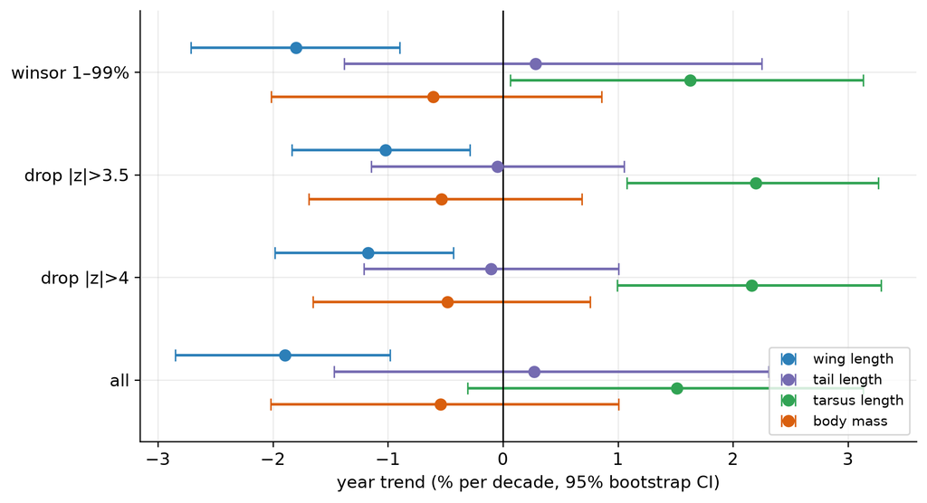

Figure 10: Year trend (% per decade, 95% species-bootstrap CI) for each trait under four outlier treatments. Body mass and tail length stay on/near zero; tarsus stays positive and strengthens as errors are removed; wing stays negative and excludes zero throughout, attenuating from ~−1.9% to ~−1.1%/decade. No trend is created, reversed or destroyed by outlier handling.

```
Year trend (%/decade, species-bootstrap CI) by trait × rule:
  wing length:
     all           : -1.89% [-2.85, -0.98]
     drop |z|>4    : -1.17% [-1.98, -0.43]
     drop |z|>3.5  : -1.02% [-1.84, -0.29]
     winsor 1–99%  : -1.80% [-2.71, -0.90]
  tail length:
     all           : +0.27% [-1.47, +2.31]
     drop |z|>4    : -0.10% [-1.21, +1.00]
     drop |z|>3.5  : -0.05% [-1.15, +1.05]
     winsor 1–99%  : +0.28% [-1.38, +2.25]
  tarsus length:
     all           : +1.51% [-0.31, +3.13]
     drop |z|>4    : +2.16% [+0.99, +3.29]
     drop |z|>3.5  : +2.20% [+1.08, +3.27]
     winsor 1–99%  : +1.63% [+0.06, +3.13]
  body mass:
     all           : -0.54% [-2.02, +1.01]
     drop |z|>4    : -0.48% [-1.65, +0.76]
     drop |z|>3.5  : -0.53% [-1.69, +0.69]
     winsor 1–99%  : -0.60% [-2.01, +0.86]
```

```python
def spp_slopes(df, resp):
    out = {}
    for sp, g in df.dropna(subset=[resp]).groupby("Binomial"):
        if g.Year.nunique() < 3 or g[resp].nunique() < 2: continue
        out[sp] = smf.ols(f"{resp} ~ scaled_yr", data=g).fit().params["scaled_yr"]
    return pd.Series(out)
def boot_ci(s, n=2000, seed=1):
    rng = np.random.RandomState(seed); v = s.values
    return np.percentile([rng.choice(v, len(v), replace=True).mean() for _ in range(n)], [2.5, 97.5])
def winsor(df, resp, lo=.01, hi=.99):
    df = df.copy()
    df[resp] = df.groupby("Binomial")[resp].transform(lambda x: x.clip(x.quantile(lo), x.quantile(hi)))
    return df

pd_ = lambda x: np.expm1(x * 10 / YR_SD) * 100
rules = ["all", "drop |z|>4", "drop |z|>3.5", "winsor 1–99%"]
sens = {}
for resp in ORDER:
    z = mad_z(d, resp)
    dsets = [d, d[~(z.abs()>4)], d[~(z.abs()>3.5)], winsor(d, resp)]
    sens[resp] = [tuple(pd_(np.r_[s.mean(), boot_ci(s)]))
                  for s in (spp_slopes(df, resp) for df in dsets)]

fig, ax = plt.subplots(figsize=(8.5, 4.7))
off = {"lnwing": .24, "lntail": .08, "lntar": -.08, "lnmass": -.24}
for resp in ORDER:
    for i, (est, lo, hi) in enumerate(sens[resp]):
        ax.errorbar(est, i+off[resp], xerr=[[est-lo],[hi-est]], fmt="o", color=COL[resp],
                    ms=7, capsize=4, lw=1.7, label=LAB[resp] if i == 0 else None)
ax.axvline(0, color="black", lw=1)
ax.set_yticks(range(len(rules))); ax.set_yticklabels(rules)
ax.set_xlabel("year trend (% per decade, 95% bootstrap CI)")
ax.legend(loc="lower right", fontsize=9); ax.set_ylim(-0.6, len(rules)-0.4)
plt.tight_layout(); plt.show()

print("Year trend (%/decade, species-bootstrap CI) by trait × rule:")
for resp in ORDER:
    print(f"  {LAB[resp]}:")
    for rule, (e, l, h) in zip(rules, sens[resp]):
        print(f"     {rule:14s}: {e:+.2f}% [{l:+.2f}, {h:+.2f}]")
```

The verdict is clean and trait-specific:

Intra-species outliers **do not drive any conclusion**. If anything, cleaning the data sharpens the picture: tarsus up, wing down, tail and mass flat.

## 13 Does museum vs live measurement confound the trends?

The dataset’s `Status` field records whether each bird was measured **live** (mist-netting; 13,102 records here) or as a **museum** specimen (skin; 2,202 records). Museum skins can differ systematically from live birds — soft tissue desiccates, feathers can shrink or shift — so if the museum:live mix changed over time, a measurement artifact could masquerade as a temporal trend. We test this directly.

### 13.1 Museum specimens are concentrated in the early years

```python
ds = d[d.Status.isin(["live", "museum"])].copy()
PER = [(1990,1999),(2000,2004),(2005,2009),(2010,2014),(2015,2018)]
print("Museum fraction of records by period:")
for lo, hi in PER:
    s = ds[(ds.Year >= lo) & (ds.Year <= hi)]
    print(f"  {lo}–{hi}: {100*(s.Status=='museum').mean():5.1f}% museum   (n = {len(s):,})")
print(f"\n  corr(museum indicator, year) = {np.corrcoef((ds.Status=='museum').astype(int), ds.Year)[0,1]:+.3f}")
```

```
Museum fraction of records by period:
  1990–1999:  40.7% museum   (n = 835)
  2000–2004:  16.6% museum   (n = 1,983)
  2005–2009:  13.5% museum   (n = 3,516)
  2010–2014:  14.0% museum   (n = 6,493)
  2015–2018:   6.0% museum   (n = 2,477)

  corr(museum indicator, year) = -0.168
```

This is exactly the setup for a confound: the museum share falls from ~41 % in the 1990s to ~6 % in 2015–2018. If museum specimens measure differently, that composition shift alone could induce an apparent trend.

### 13.2 Status shifts the measurements — strongly for tail and mass

We estimate the within-species museum-vs-live difference for each trait (`trait ~ status + sex + latitude`, species random intercept).

```python
rows = []
for resp in ORDER:
    sub = ds.dropna(subset=[resp]).copy()
    f = smf.mixedlm(f"{resp} ~ C(Status) + C(Sex) + scaled_lat", sub,
                    groups=sub["Binomial"]).fit(method="lbfgs")
    c = f.params["C(Status)[T.museum]"]; se = f.bse["C(Status)[T.museum]"]
    rows.append([LAB[resp], f"{np.expm1(c)*100:+.2f}%",
                 f"[{np.expm1(c-1.96*se)*100:+.2f}, {np.expm1(c+1.96*se)*100:+.2f}]",
                 f"{f.pvalues['C(Status)[T.museum]']:.3f}", int((sub.Status=='museum').sum())])
pd.DataFrame(rows, columns=["trait", "museum vs live", "95% CI", "p", "n museum"])
```

|  | trait | museum vs live | 95% CI | p | n museum |
| --- | --- | --- | --- | --- | --- |
| 0 | wing length | +0.35% | [-0.14, +0.84] | 0.163 | 1154 |
| 1 | tail length | +5.02% | [+4.16, +5.89] | 0.000 | 1204 |
| 2 | tarsus length | +1.09% | [+0.16, +2.04] | 0.022 | 1223 |
| 3 | body mass | -1.78% | [-2.56, -0.99] | 0.000 | 1985 |

Status genuinely affects the measurements: museum **tail length** reads ~5 % longer and museum **body mass** ~1.8 % lighter (both p < 0.001), museum tarsus ~1 % longer (p = 0.02), while **wing length is essentially unaffected** (+0.35 %, n.s.). Because museum specimens dominate the early years, these biases could in principle distort the temporal trends — so we re-estimate every trend four ways.

### 13.3 The trends are robust to status — with one caveat (tail)

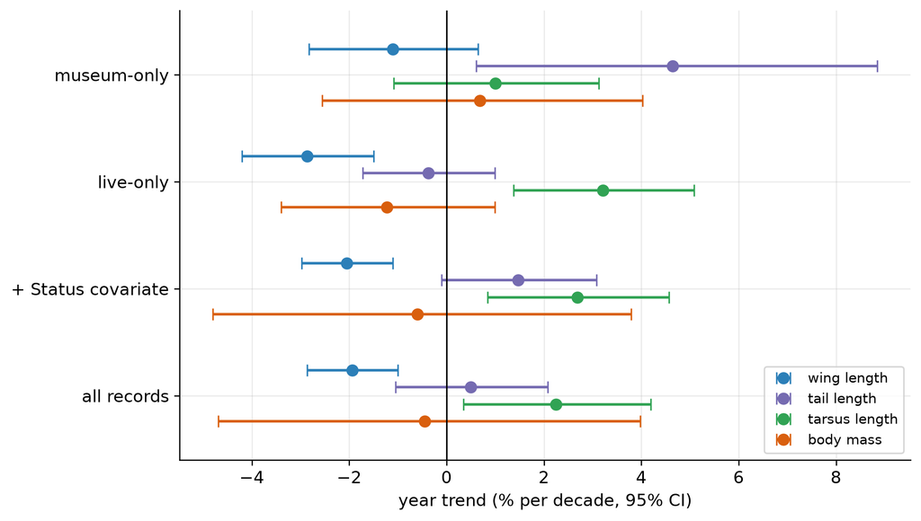

Figure 11: Year trend (% per decade, 95% CI) for each trait under four status treatments: all records, adding Status as a covariate, live-only, and museum-only. Wing’s decline and tarsus’s increase are robust (and strengthen once status is accounted for); body mass stays flat throughout. Tail length is the exception — flat-to-negative on live records but positive on the (early, sparse) museum records — so tail trends are entangled with status.

```
wing length:
   all records         : -1.94%/dec [-2.87, -1.00] p=0.000
   + Status covariate  : -2.05%/dec [-2.98, -1.10] p=0.000
   live-only           : -2.86%/dec [-4.20, -1.50] p=0.000
   museum-only         : -1.10%/dec [-2.82, +0.65] p=0.215
tail length:
   all records         : +0.50%/dec [-1.05, +2.07] p=0.530
   + Status covariate  : +1.47%/dec [-0.10, +3.08] p=0.067
   live-only           : -0.37%/dec [-1.72, +1.00] p=0.594
   museum-only         : +4.65%/dec [+0.61, +8.85] p=0.024
tarsus length:
   all records         : +2.25%/dec [+0.35, +4.19] p=0.020
   + Status covariate  : +2.69%/dec [+0.84, +4.57] p=0.004
   live-only           : +3.22%/dec [+1.38, +5.09] p=0.001
   museum-only         : +1.00%/dec [-1.09, +3.13] p=0.350
body mass:
   all records         : -0.45%/dec [-4.69, +3.98] p=0.839
   + Status covariate  : -0.60%/dec [-4.80, +3.79] p=0.786
   live-only           : -1.23%/dec [-3.40, +1.00] p=0.277
   museum-only         : +0.68%/dec [-2.56, +4.02] p=0.684
```

```python
def yreff(df, resp, extra=""):
    sub = df.dropna(subset=[resp]).copy()
    f = smf.mixedlm(f"{resp} ~ C(Sex)+scaled_yr+scaled_lat{extra}", sub,
                    groups=sub["Binomial"], re_formula="~scaled_yr").fit(method="lbfgs")
    b1, se = f.params["scaled_yr"], f.bse["scaled_yr"]; g = 10/YR_SD
    return (np.expm1(b1*g)*100, np.expm1((b1-1.96*se)*g)*100, np.expm1((b1+1.96*se)*g)*100,
            f.pvalues["scaled_yr"])

treat = ["all records", "+ Status covariate", "live-only", "museum-only"]
stat = {}
for resp in ORDER:
    stat[resp] = [yreff(ds, resp), yreff(ds, resp, "+C(Status)"),
                  yreff(ds[ds.Status=="live"], resp), yreff(ds[ds.Status=="museum"], resp)]

fig, ax = plt.subplots(figsize=(8.5, 4.9))
off = {"lnwing": .24, "lntail": .08, "lntar": -.08, "lnmass": -.24}
for resp in ORDER:
    for i, (est, lo, hi, p) in enumerate(stat[resp]):
        ax.errorbar(est, i+off[resp], xerr=[[est-lo],[hi-est]], fmt="o", color=COL[resp],
                    ms=7, capsize=4, lw=1.7, label=LAB[resp] if i == 0 else None)
ax.axvline(0, color="black", lw=1)
ax.set_yticks(range(len(treat))); ax.set_yticklabels(treat)
ax.set_xlabel("year trend (% per decade, 95% CI)")
ax.legend(loc="lower right", fontsize=9); ax.set_ylim(-0.6, len(treat)-0.4)
plt.tight_layout(); plt.show()

for resp in ORDER:
    print(f"{LAB[resp]}:")
    for t, (e, l, h, p) in zip(treat, stat[resp]):
        print(f"   {t:20s}: {e:+.2f}%/dec [{l:+.2f}, {h:+.2f}] p={p:.3f}")
```

The picture is reassuring for three of four traits:

- **Wing length** — decline robust everywhere: ~−1.9 %/decade at baseline, *stronger* once Status is controlled (−2.1 %) and on **live-only** records (−2.9 %, p < 0.001). Museum-only is the same direction (−1.1 %) but n.s. on its small, early sample. Since museum wing is barely different and museum records sit early, the confound if anything *suppresses* the decline slightly — the real signal is cleaner.
- **Tarsus length** — increase robust and *strengthens* once status is controlled (+2.7 %) and on live-only (+3.2 %). Museum tarsus reads larger and sits early, so the confound partly *masks* the increase; removing it sharpens the signal.
- **Body mass** — flat under every treatment (CI always spans zero). No status artifact creates or hides a mass trend.
- **Tail length** — the **caveat**. Tail is the most status-sensitive trait (+5 % museum bias) and its weak signal flips with treatment: flat-to-negative on live-only (−0.4 %/decade) but strongly positive on the early, sparse museum records (+4.6 %). Any tail trend is therefore entangled with status and should be read from the **live-only** estimate.

Finally, the recent (2015–2018) feather-trait drop from Section 8 survives restricting to live birds — so it is not a museum artifact (the recent bins are ~94 % live anyway):

```python
for resp, lab in [("lnwing","wing"), ("lntail","tail")]:
    for tag, sub0 in [("all ", ds), ("live", ds[ds.Status=="live"])]:
        sub = sub0.dropna(subset=[resp]).copy()
        sub["dev"] = (sub[resp] - sub.groupby("Binomial")[resp].transform("mean")) * 100
        v = sub[(sub.Year >= 2015) & (sub.Year <= 2018)]["dev"]
        print(f"  {lab} {tag}: 2015–2018 within-species deviation = {v.mean():+.2f}% (n {len(v)})")
```

```
  wing all : 2015–2018 within-species deviation = -1.68% (n 2064)
  wing live: 2015–2018 within-species deviation = -1.71% (n 2027)
  tail all : 2015–2018 within-species deviation = -1.74% (n 2014)
  tail live: 2015–2018 within-species deviation = -1.07% (n 1975)
```

**Bottom line:** museum-vs-live status is a real measurement effect and is confounded with time (museum early), but it does **not** drive the core inferences. Controlling for it leaves the wing decline and tarsus increase intact (both *strengthen*), and body mass flat. The only trait whose trend is genuinely status-dependent is tail length, whose net signal is weak and best taken from live-only records.

## 14 Conclusions

In short: bringing in tail length and tarsus shows the wing-length decline is **specific**, not a coordinated body-size reduction — body mass does not decline because there is no whole-body shrinkage to detect. Yet the two feather traits fall together in the most recent years, a non-linear signal that deserves a closer look.

*Reproduce this report:*

```bash
# from Analysis/scripts/, with a Python env that has
# pandas numpy matplotlib scipy statsmodels jupyter ipykernel
QUARTO_PYTHON=../../.venv-massreport/bin/python \
  quarto render body_mass_descriptive.qmd
```